# Progetto Finale Catanzaro

# Breaking bad

la rete di relazioni tra i vari personaggi è complessa e spesso come accade nelle serie come questa, il protagonista si relaziona con diversi gruppi di persone che durante la maggior parte del tempo non interagiscono tra loro, ma improvvisamente avvengono plot twist che cambiano tutto, che è proprio cio che scombussola l’equilibrio narrativo.

```
## # A tbl_graph: 113 nodes and 408 edges
## #
## # An undirected simple graph with 1 component
## #
## # Node Data: 113 × 1 (active)
##    name
##    <chr>
##  1 Andrea Cantillo
##  2 Badger
##  3 Ben
##  4 Benicio Fuentes
##  5 Bogdan
##  6 Brock Cantillo
##  7 Cara
##  8 Carmen Molina
##  9 Chad
## 10 Chad Girlfriend
## # ℹ 103 more rows
## #
## # Edge Data: 408 × 63
##    from    to `01S1` `02S1` `03S1` `04S1` `05S1` `06S1` `07S1` `01S2` `02S2`
##   <int> <int>  <dbl>  <dbl>  <dbl>  <dbl>  <dbl>  <dbl>  <dbl>  <dbl>  <dbl>
## 1     1     2      0      0      0      0      0      0      0      0      0
## 2     1     6      0      0      0      0      0      0      0      0      0
## 3     1    61      0      0      0      0      0      0      0      0      0
## # ℹ 405 more rows
## # ℹ 52 more variables: `03S2` <dbl>, `04S2` <dbl>, `05S2` <dbl>, `06S2` <dbl>,
## #   `07S2` <dbl>, `08S2` <dbl>, `09S2` <dbl>, `10S2` <dbl>, `11S2` <dbl>,
## #   `12S2` <dbl>, `13S2` <dbl>, `02S3` <dbl>, `03S3` <dbl>, `04S3` <dbl>,
## #   `05S3` <dbl>, `06S3` <dbl>, `07S3` <dbl>, `08S3` <dbl>, `09S3` <dbl>,
## #   `10S3` <dbl>, `11S3` <dbl>, `12S3` <dbl>, `13S3` <dbl>, `01S4` <dbl>,
## #   `02S4` <dbl>, `03S4` <dbl>, `04S4` <dbl>, `05S4` <dbl>, `06S4` <dbl>, …
```

```
## # A tbl_graph: 113 nodes and 408 edges
## #
## # An undirected simple graph with 1 component
## #
## # Edge Data: 408 × 66 (active)
##     from    to Nome_from       Nome_to Totale `01S1` `02S1` `03S1` `04S1` `05S1`
##    <int> <int> <chr>           <chr>    <dbl>  <dbl>  <dbl>  <dbl>  <dbl>  <dbl>
##  1    61   111 Jesse Pinkman   Walter…    191      5      8      2      1      1
##  2    94   111 Skyler White    Walter…    161      6      3      2      6      7
##  3   111   112 Walter White    Walter…     89      4      1      0      4      3
##  4    94   112 Skyler White    Walter…     71      3      1      1      2      4
##  5    49    77 Hank Schrader   Marie …     58      2      0      1      2      2
##  6    61    78 Jesse Pinkman   Mike E…     56      0      0      0      0      0
##  7    49    99 Hank Schrader   Steven…     54      2      0      1      1      0
##  8    77    94 Marie Schrader  Skyler…     51      2      0      1      2      2
##  9    49   111 Hank Schrader   Walter…     45      3      0      0      2      1
## 10    78   111 Mike Ehrmantra… Walter…     44      0      0      0      0      0
## # ℹ 398 more rows
## # ℹ 56 more variables: `06S1` <dbl>, `07S1` <dbl>, `01S2` <dbl>, `02S2` <dbl>,
## #   `03S2` <dbl>, `04S2` <dbl>, `05S2` <dbl>, `06S2` <dbl>, `07S2` <dbl>,
## #   `08S2` <dbl>, `09S2` <dbl>, `10S2` <dbl>, `11S2` <dbl>, `12S2` <dbl>,
## #   `13S2` <dbl>, `02S3` <dbl>, `03S3` <dbl>, `04S3` <dbl>, `05S3` <dbl>,
## #   `06S3` <dbl>, `07S3` <dbl>, `08S3` <dbl>, `09S3` <dbl>, `10S3` <dbl>,
## #   `11S3` <dbl>, `12S3` <dbl>, `13S3` <dbl>, `01S4` <dbl>, `02S4` <dbl>, …
## #
## # Node Data: 113 × 1
##   name
##   <chr>
## 1 Andrea Cantillo
## 2 Badger
## 3 Ben
## # ℹ 110 more rows
```

# Descrizione del grafo

Il grafo `graph_bb` rappresenta la **rete delle co-presenze** tra i personaggi della serie *Breaking Bad*.

- **Nodi (V)**: personaggi della serie (inclusi alcuni personaggi secondari e comparse rilevanti, quando hanno un ruolo non marginale nella narrazione).
- **Archi (E)**: una coppia di personaggi $(u,v)$ è collegata se i due hanno **co-partecipato ad almeno una scena** nell’intera serie.

## Pesi degli archi e dettaglio temporale

Ogni arco contiene, oltre all’informazione di esistenza del legame, anche il **numero esatto di scene** in cui la coppia co-partecipa:

- è disponibile un conteggio **per ogni episodio di ogni stagione** (es. colonne del tipo `01S1`, `02S1`, …),
- ed è presente anche un valore aggregato (`Totale`) che rappresenta la **forza complessiva** del legame lungo tutta la serie.

In questo modo, il grafo è un **grafo pesato**: il peso di un arco misura **quanto è intensa e frequente** l’interazione tra due personaggi (più scene condivise ⇒ legame più forte).  
Inoltre, avendo il dettaglio per episodio, è possibile studiare l’**evoluzione temporale** delle relazioni e osservare come cambiano i collegamenti tra i personaggi nel corso della narrazione.

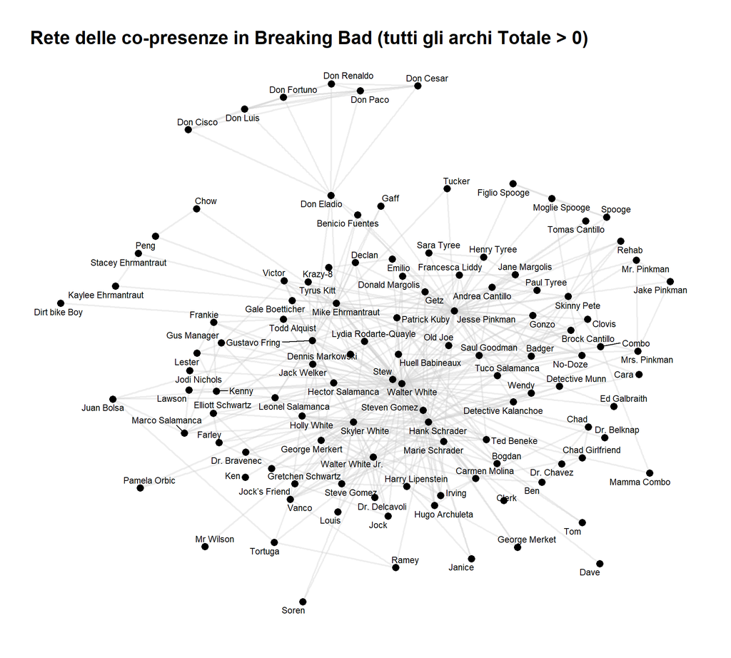